# REACCIONES QUíMICAS

Jesenia Paitan

2022/05/18

## INTRODUCCIÓN

Las moléculas, como aquellas que componen tu cuerpo, son solo colecciones de átomos que están unidos por enlaces químicos.

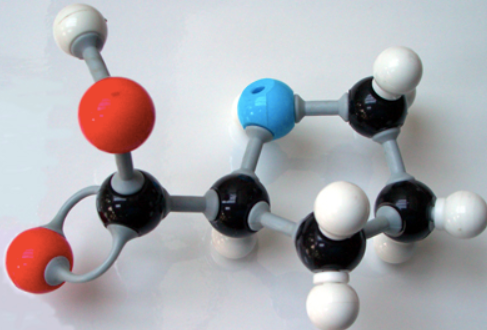

## REACCIONES QUÍMICAS

Las reacciones químicas suceden cuando se rompen o se forman enlaces químicos entre los átomos. Las sustancias que participan en una reacción química se conocen como los reactivos, y las sustancias que se producen al final de la reacción se conocen como los productos

$$\left.\left.2 \mathrm{H}_{2} \mathrm{O}_{2} \text { (peróxido de
hidrógeno }\right) \rightarrow 2 \mathrm{H}_{2} \mathrm{O}(\text { agua
})+\mathrm{O}_{2} \text { (oxígeno }\right)$$

[video not shown]

# Reacciones de precipitación

Cuando dos soluciones se mezclan y se forma una sustancia sólida que no se disuelve estamos en presencia de una reacción de precipitación.

Ejemplo:

$$\mathrm{AgNO}_{3(1)}+\mathrm{KCl}_{(1)} \rightarrow \mathrm{AgCl}_{\text
{(sólido blanco) }}+\mathrm{KNO}_{3(1)}$$

# Reacciones ácido-base o de neutralización

Un ácido es una sustancia que aumenta la concentración de iones hidrógeno (H+) en una solución cuando se disocia alguno de sus átomos de hidrógeno.

Ejemplo:

$$\mathrm{H}_{2} \mathrm{SO}_{4(\mathrm{ac})}+2
\mathrm{NaOH}_{(\mathrm{ac})} \rightarrow \mathrm{Na}_{2}
\mathrm{SO}_{4(\mathrm{ac})}+2 \mathrm{H}_{2} \mathrm{O}_{(\mathrm{l})}$$

# Reacciones de óxido-reducción

En las reacciones de óxido-reducción o también llamadas reacciones redox hay transferencia de electrones entre los reactantes.

Ejemplo:

$$\mathrm{H}_{2} \mathrm{~S}+\mathrm{Cl}_{2} \rightarrow 2
\mathrm{HCl}+\mathrm{S}$$

# Reacciones de combinación

Las reacciones de combinación involucran la unión de elementos o moléculas para formar un compuesto.

Ejemplo:

$$A+B \rightarrow A B$$

# Reacciones de descomposición

En el caso de las reacciones de descomposición, un compuesto se divide en sus componentes.

Ejemplo:

$$A B \rightarrow A+B$$

## VELOCIDAD DE REACCIÓN

La velocidad de reacción se define como la cantidad de sustancia que se transforma en una determinada reacción por unidad de tiempo.

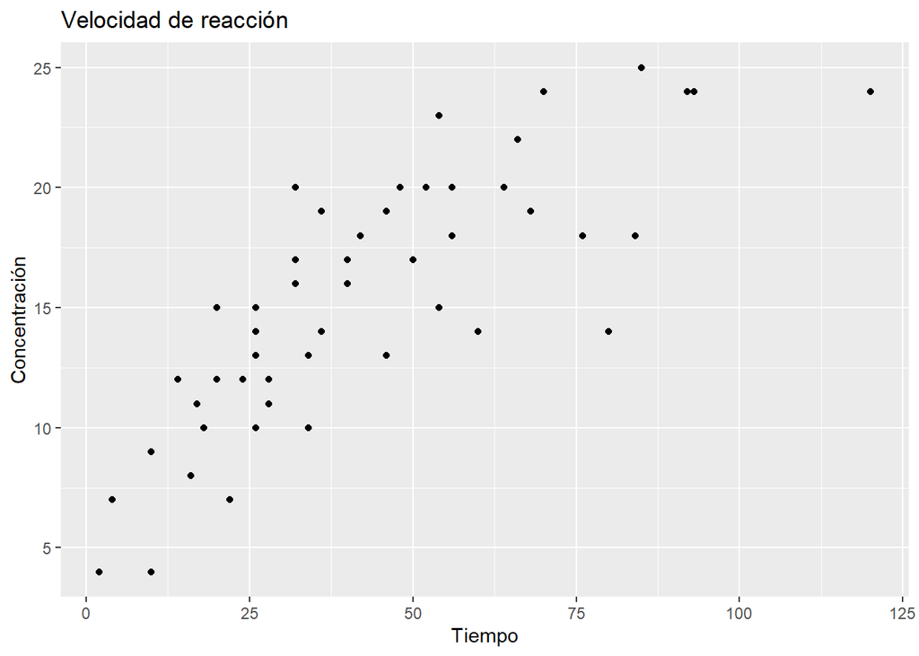

Para más información:

[interactive chart not shown]